# UKB - Heteroplasmy, CHIP, and MN

01 - descriptive analysis: Tables 1-2, Figures 1-3, Supplementary Table 4, and Supplementary Figure 9

Yun Soo Hong, Sergiu Pasca

November 03, 2024

# 1 Set up

## 1.1 Program description

- This program reads in the cleaned data set (`ukb_mthet_chip_dp3_2024_03_13.rds`), performs analysis in the “Mitochondrial heteroplasmy improves risk prediction for myeloid neoplasms” paper (Nature Communications, 2024), and provided the data used for generating tables and figures.
- This file contains
  - Table 1, Table 2, Figure 1, Figure 2, Figure 3, Supplementary Table 4, Supplementary Figure 1, and Supplementary Figure 9.
- Steps
  - Step 1: Read in data
  - Step 2: Settings
  - Step 3: Table 1
  - Step 4: Table 2
  - Step 5: Figure 1
  - Step 6: Figure 2
  - Step 7: Supplementary Table 4
  - Step 8: Supplementary Figure 1
  - Step 9: Supplementary Figure 9

## 1.2 Version of R and packages

## 1.3 Load libraries

```r
library(tidyverse)
library(magrittr)
library(lubridate)
library(stringr)
library(data.table)
library(table1)
```

## 1.4 Print out settings

```r
options(tibble.print_max = 100)
options(pillar.sigfig = 5)
```

# 2 Load data

## 2.1 All participants

## 2.2 CHIP variants

# 3 Settings

## 3.1 Descriptive tables

### 3.1.1 Labels and units in all participants

```r
# Labels
label(ukb$age)          <- "Age"
label(ukb$sex)          <- "Sex"
label(ukb$race_new)     <- "Self-reported race"
label(ukb$smk_ever)       <- "Ever smoker"
label(ukb$anemia)       <- "Anemia"
label(ukb$thrombocytopenia)   <- "Thrombocytopenia"
label(ukb$neutropenia)        <- "Neutropenia"
label(ukb$cytopenia_yn)       <- "Cytopenia"
label(ukb$mcv)       <- "Mean corpuscular volume"
label(ukb$rbcdw)     <- "Red cell distribution width"
label(ukb$prev_cancer_yn)     <- "History of cancer"
label(ukb$het_fct)    <- "Heteroplasmy (+)"
label(ukb$chip_fct)   <- "CHIP (+)"
label(ukb$count_het) <- "Heteroplasmy count"
label(ukb$mMSS)      <- "mMSS"
label(ukb$age65_yn)  <- "Age 65+"
label(ukb$ccus)      <- "CCUS"
label(ukb$rdw_cat)   <- "RDW 15+"
label(ukb$mcv_cat)   <- "MCV 100+"
label(ukb$high_risk_fct) <- "High-risk mutation"
label(ukb$single_dnmt3a_fct) <- "Single DNMT3A"
label(ukb$mutation_n_fct) <- "Number of mutations 2+"
label(ukb$max_vaf_fct) <- "VAF 20+"

# Units
units(ukb$age)       <- "years"
units(ukb$sex)       <- "%"
units(ukb$race_new)  <- "%"
units(ukb$smk_ever)  <- "%"
units(ukb$anemia)    <- "%"
units(ukb$thrombocytopenia)   <- "%"
units(ukb$neutropenia)        <- "%"
units(ukb$cytopenia_yn)       <- "%"
units(ukb$mcv)       <- "fL"
units(ukb$rbcdw)     <- "%"
units(ukb$prev_cancer_yn)     <- "%"
units(ukb$het_fct)    <- "%"
units(ukb$chip_fct)   <- "%"
units(ukb$count_het) <- ""
units(ukb$mMSS)      <- ""
units(ukb$age65_yn)  <- "%"
units(ukb$ccus)      <- "%"
units(ukb$rdw_cat)   <- "%"
units(ukb$mcv_cat)   <- "%"
units(ukb$high_risk_fct) <- "%"
units(ukb$single_dnmt3a_fct) <- "%"
units(ukb$mutation_n_fct) <- "%"
units(ukb$max_vaf_fct) <- "%"
```

### 3.1.2 Labels and units in CHIP (+) participants

```r
# Labels
label(ukb_chip$age)          <- "Age"
label(ukb_chip$sex)          <- "Sex"
label(ukb_chip$race_new)     <- "Self-reported race"
label(ukb_chip$smk_ever)       <- "Ever smoker"
label(ukb_chip$anemia)       <- "Anemia"
label(ukb_chip$thrombocytopenia)   <- "Thrombocytopenia"
label(ukb_chip$neutropenia)        <- "Neutropenia"
label(ukb_chip$cytopenia_yn)       <- "Cytopenia"
label(ukb_chip$mcv)       <- "Mean corpuscular volume"
label(ukb_chip$rbcdw)     <- "Red cell distribution width"
label(ukb_chip$prev_cancer_yn)     <- "History of cancer"
label(ukb_chip$het_fct)    <- "Heteroplasmy (+)"
label(ukb_chip$chip_fct)   <- "CHIP (+)"
label(ukb_chip$count_het) <- "Heteroplasmy count"
label(ukb_chip$mMSS)      <- "mMSS"
label(ukb_chip$age65_yn)  <- "Age 65+"
label(ukb_chip$ccus)      <- "CCUS"
label(ukb_chip$rdw_cat)   <- "RDW 15+"
label(ukb_chip$mcv_cat)   <- "MCV 100+"
label(ukb_chip$high_risk_fct) <- "High-risk mutation"
label(ukb_chip$single_dnmt3a_fct) <- "Single DNMT3A"
label(ukb_chip$mutation_n_fct) <- "Number of mutations 2+"
label(ukb_chip$max_vaf_fct) <- "VAF 20+"

# Units
units(ukb_chip$age)       <- "years"
units(ukb_chip$sex)       <- "%"
units(ukb_chip$race_new)  <- "%"
units(ukb_chip$smk_ever)  <- "%"
units(ukb_chip$anemia)    <- "%"
units(ukb_chip$thrombocytopenia)   <- "%"
units(ukb_chip$neutropenia)        <- "%"
units(ukb_chip$cytopenia_yn)       <- "%"
units(ukb_chip$mcv)       <- "fL"
units(ukb_chip$rbcdw)     <- "%"
units(ukb_chip$prev_cancer_yn)     <- "%"
units(ukb_chip$het_fct)    <- "%"
units(ukb_chip$chip_fct)   <- "%"
units(ukb_chip$age65_yn)  <- "%"
units(ukb_chip$ccus)      <- "%"
units(ukb_chip$rdw_cat)   <- "%"
units(ukb_chip$mcv_cat)   <- "%"
units(ukb_chip$high_risk_fct) <- "%"
units(ukb_chip$single_dnmt3a_fct) <- "%"
units(ukb_chip$mutation_n_fct) <- "%"
units(ukb_chip$max_vaf_fct) <- "%"
```

## 3.2 Function

```r
# function for continuous variables
my.render.cont <- function(x) {
  with(stats.apply.rounding(stats.default(x), digits = 4),
       c("", "Mean (SD)" = sprintf("%s (&plusmn; %s)", MEAN, SD)))
}

my.render.cont <-
  function(x) {
    with(
      stats.apply.rounding(stats.default(x), digits = 4),
      c("", "Mean (SD)" = sprintf("%s (&plusmn; %s)", MEAN, SD))
    )
  }

# function for categorical variables
my.render.cat <-
  function(x) {
    c("",
      sapply(
        stats.default(x),
        function(y)
          with(y, sprintf("%d (%0.1f %%)", FREQ, PCT))
      )
    )
  }

# function for p-values
pvalue <-
  function(x, ...) {
    y <- unlist(x)
    g <- factor(
      rep(1:length(x),
          times = sapply(x, length))
      )
    if (is.numeric(y)) {
      p <- summary(lm(y ~ as.numeric(g)))$coefficients[, 4][2]
    } else {
      p <- chisq.test(table(y, g))$p.value
    }
    c("", sub("<", "&lt;", format.pval(p, digits = 4, eps = 0.0001)))
  }
```

# 4 Table 1 - Participant characteristics by presence of CHIP in each cohort.

```r
table1::table1(
  ~ age + sex + race_new + smk_ever + anemia + thrombocytopenia + neutropenia + cytopenia_yn + mcv + rbcdw + prev_cancer_yn + het_fct |
  chip_fct,
  data = ukb,
  overall = F,
  render.continuous = my.render.cont,
  extra.col = list(`P value` = pvalue)
  )
```

|  | CHIP (-) (N=400707) | CHIP (+) (N=33597) | P value |
| --- | --- | --- | --- |
| Age (years) |  |  |  |
| Mean (SD) | 56.29 (± 8.093) | 58.86 (± 7.575) | < 1e-04 |
| Sex (%) |  |  |  |
| women | 216715 (54.1%) | 18543 (55.2%) | < 1e-04 |
| men | 183992 (45.9%) | 15054 (44.8%) |  |
| Self-reported race (%) |  |  |  |
| white | 378247 (94.4%) | 32066 (95.4%) | < 1e-04 |
| black | 6193 (1.5%) | 421 (1.3%) |  |
| asian | 8985 (2.2%) | 603 (1.8%) |  |
| others | 5952 (1.5%) | 394 (1.2%) |  |
| missing | 1330 (0.3%) | 113 (0.3%) |  |
| Ever smoker (%) |  |  |  |
| no | 162129 (40.5%) | 12639 (37.6%) | < 1e-04 |
| yes | 238578 (59.5%) | 20958 (62.4%) |  |
| Anemia (%) |  |  |  |
| 0 | 383887 (95.8%) | 32071 (95.5%) | 0.002689 |
| 1 | 16820 (4.2%) | 1526 (4.5%) |  |
| Thrombocytopenia (%) |  |  |  |
| 0 | 392031 (97.8%) | 32768 (97.5%) | 0.0002964 |
| 1 | 8676 (2.2%) | 829 (2.5%) |  |
| Neutropenia (%) |  |  |  |
| 0 | 396643 (99.0%) | 33207 (98.8%) | 0.01128 |
| 1 | 4064 (1.0%) | 390 (1.2%) |  |
| Cytopenia (%) |  |  |  |
| 0 | 372470 (93.0%) | 31034 (92.4%) | < 1e-04 |
| 1 | 28237 (7.0%) | 2563 (7.6%) |  |
| Mean corpuscular volume (fL) |  |  |  |
| Mean (SD) | 91.11 (± 4.563) | 91.28 (± 4.629) | < 1e-04 |
| Red cell distribution width (%) |  |  |  |
| Mean (SD) | 13.48 (± 0.9693) | 13.56 (± 1.051) | < 1e-04 |
| History of cancer (%) |  |  |  |
| 0 | 373078 (93.1%) | 30654 (91.2%) | < 1e-04 |
| 1 | 27629 (6.9%) | 2943 (8.8%) |  |
| Heteroplasmy (+) (%) |  |  |  |
| Heteroplasmy (-) | 289183 (72.2%) | 22152 (65.9%) | < 1e-04 |
| Heteroplasmy (+) | 111524 (27.8%) | 11445 (34.1%) |  |

# 5 Table 2 - Participant characteristics by the presence of heteroplasmy in each cohort.

```r
table1::table1(
  ~ age + sex + race_new + smk_ever + anemia + thrombocytopenia + neutropenia + cytopenia_yn + mcv + rbcdw + prev_cancer_yn + chip_fct |
  het_fct,
  data = ukb,
  overall = F,
  render.continuous = my.render.cont,
  extra.col = list(`P value` = pvalue)
  )
```

|  | Heteroplasmy (-) (N=311335) | Heteroplasmy (+) (N=122969) | P value |
| --- | --- | --- | --- |
| Age (years) |  |  |  |
| Mean (SD) | 56.22 (± 8.087) | 57.17 (± 8.035) | < 1e-04 |
| Sex (%) |  |  |  |
| women | 169175 (54.3%) | 66083 (53.7%) | 0.0003624 |
| men | 142160 (45.7%) | 56886 (46.3%) |  |
| Self-reported race (%) |  |  |  |
| white | 293487 (94.3%) | 116826 (95.0%) | < 1e-04 |
| black | 4934 (1.6%) | 1680 (1.4%) |  |
| asian | 7186 (2.3%) | 2402 (2.0%) |  |
| others | 4667 (1.5%) | 1679 (1.4%) |  |
| missing | 1061 (0.3%) | 382 (0.3%) |  |
| Ever smoker (%) |  |  |  |
| no | 126598 (40.7%) | 48170 (39.2%) | < 1e-04 |
| yes | 184737 (59.3%) | 74799 (60.8%) |  |
| Anemia (%) |  |  |  |
| 0 | 298231 (95.8%) | 117727 (95.7%) | 0.4312 |
| 1 | 13104 (4.2%) | 5242 (4.3%) |  |
| Thrombocytopenia (%) |  |  |  |
| 0 | 304690 (97.9%) | 120109 (97.7%) | 0.0001074 |
| 1 | 6645 (2.1%) | 2860 (2.3%) |  |
| Neutropenia (%) |  |  |  |
| 0 | 308159 (99.0%) | 121691 (99.0%) | 0.5837 |
| 1 | 3176 (1.0%) | 1278 (1.0%) |  |
| Cytopenia (%) |  |  |  |
| 0 | 289393 (93.0%) | 114111 (92.8%) | 0.0727 |
| 1 | 21942 (7.0%) | 8858 (7.2%) |  |
| Mean corpuscular volume (fL) |  |  |  |
| Mean (SD) | 91.09 (± 4.540) | 91.21 (± 4.639) | < 1e-04 |
| Red cell distribution width (%) |  |  |  |
| Mean (SD) | 13.48 (± 0.9732) | 13.50 (± 0.9835) | < 1e-04 |
| History of cancer (%) |  |  |  |
| 0 | 290118 (93.2%) | 113614 (92.4%) | < 1e-04 |
| 1 | 21217 (6.8%) | 9355 (7.6%) |  |
| CHIP (+) (%) |  |  |  |
| CHIP (-) | 289183 (92.9%) | 111524 (90.7%) | < 1e-04 |
| CHIP (+) | 22152 (7.1%) | 11445 (9.3%) |  |

# 6 Figure 1 - Description of CHIP mutations

## 6.1 Figure 1a

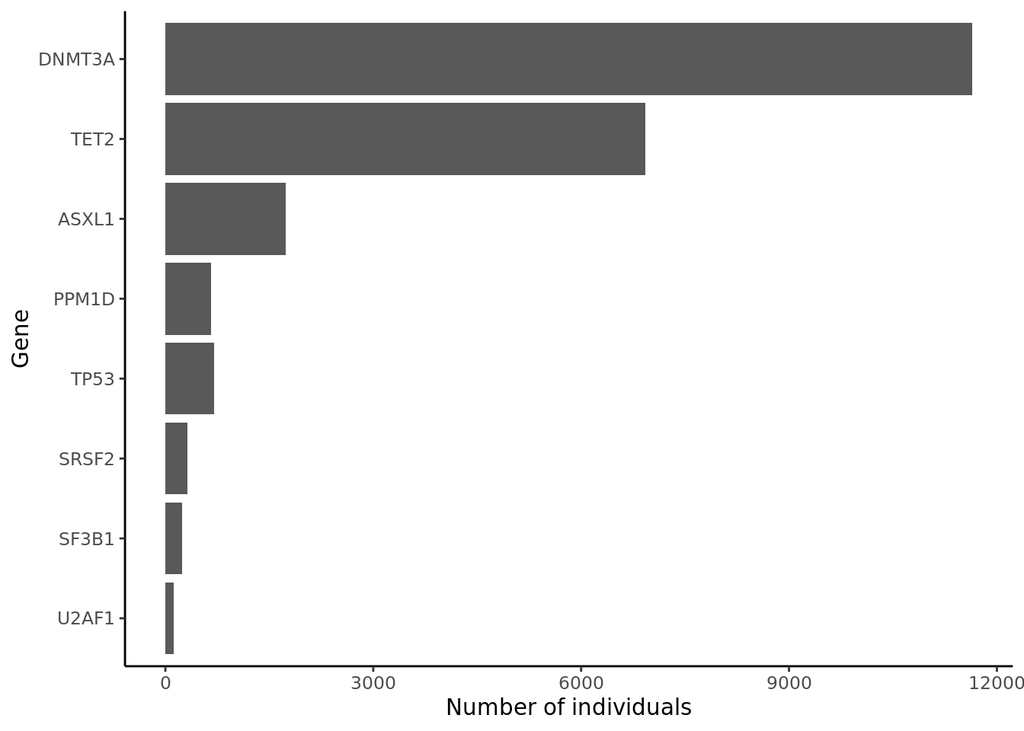

```r
gene_list <- c("DNMT3A", "TET2", "ASXL1", "PPM1D","TP53", "SRSF2", "SF3B1", "U2AF1")

chip_fq_sum <-
  chip_var |>
  group_by(Gene.refGene) |>
  summarise(n = n()) |>
  arrange(-n)

fig1a <-
  chip_fq_sum |>
  filter(
    Gene.refGene %in% gene_list
  ) |>
  mutate(
    Gene.refGene = factor(
      Gene.refGene,
      levels = rev(gene_list)
    )
  ) |>
  ggplot() +
  geom_col(aes(x = Gene.refGene, y = n)) +
  theme_classic() +
  coord_flip() +
  scale_x_discrete("Gene") +
  scale_y_continuous("Number of individuals")
fig1a
```

## 6.2 Figure 1c

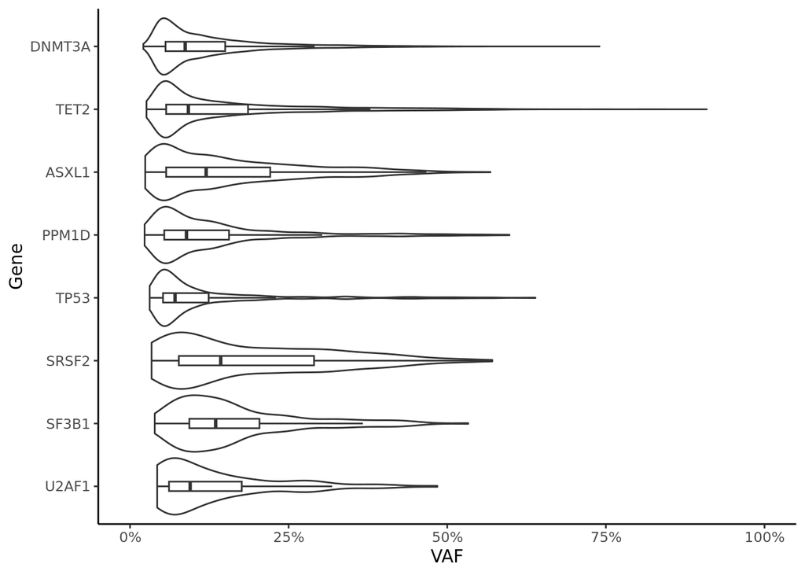

```r
fig1c <- chip_var |>
  filter(Gene.refGene %in% gene_list) |>
  mutate(
    Gene.refGene = factor(
      Gene.refGene,
      levels = rev(gene_list)
    )
  ) |>
  ggplot() +
  geom_violin(aes(x = Gene.refGene, y = VAF), scale = "width") +
  geom_boxplot(aes(x = Gene.refGene, y = VAF), alpha = 0, width = 0.15) +
  theme_classic() +
  coord_flip() +
  scale_x_discrete("Gene") +
  scale_y_continuous("VAF", breaks = c(0, 25, 50, 75, 100),
                     labels = paste0(c(0, 25, 50, 75, 100), "%"),
                     limits = c(0, 100))
fig1c
```

## 6.3 Figure 1e

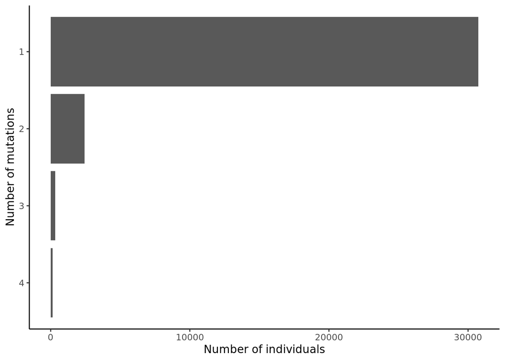

```r
fig1e <- chip_var |>
  group_by(SampID) |>
  summarise(
    n = n()
  ) |>
  ungroup() |>
  mutate(n = ifelse(n > 3, 4, n)) |>
  group_by(n) |>
  summarise(
    obs = n()
  ) |>
  ggplot() +
  geom_col(aes(x = obs, y = reorder(n, -n))) +
  theme_classic() +
  scale_x_continuous("Number of individuals") +
  scale_y_discrete("Number of mutations")
fig1e
```

# 7 Figure 2 - Description of heteroplasmy

## 7.1 Figure 2a

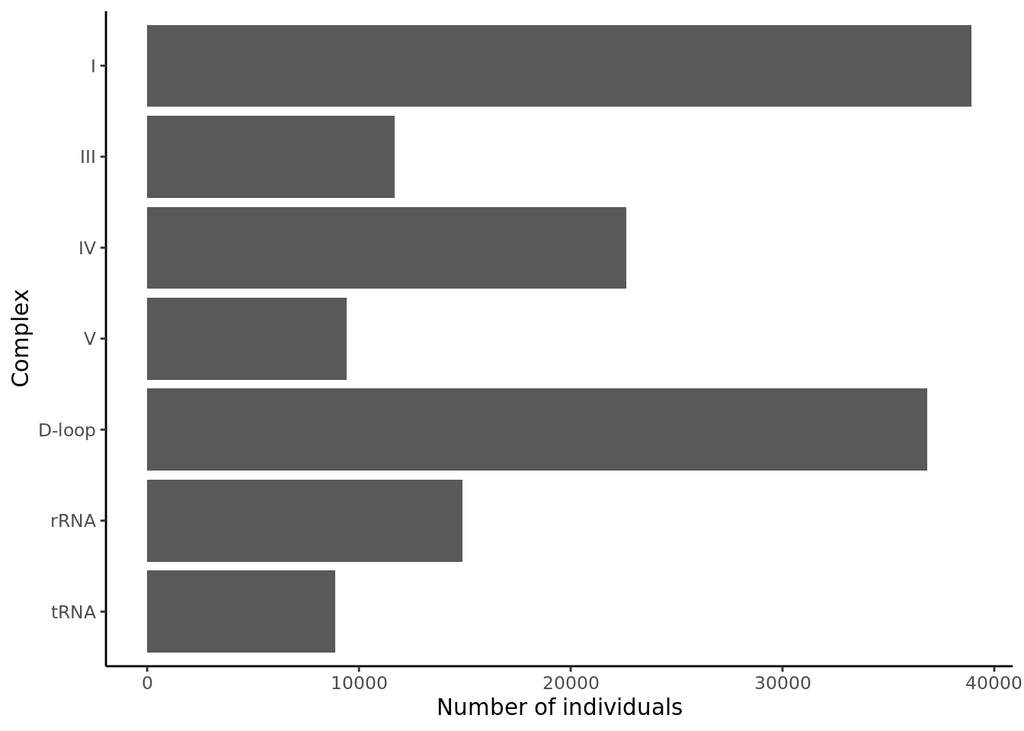

```r
ukb_hc_long <-
  ukb |>
  dplyr::select(id, starts_with("hetcount_complex_")) |>
  pivot_longer(
    cols = !id,
    names_to = "variable",
    values_to = "value"
  ) |>
  mutate(
    complex = str_remove(variable, "hetcount_complex_")
  )

fig2a <-
  ukb_hc_long |>
  filter(value != 0) |>
  group_by(variable) |>
  summarise(n = n()) |>
  mutate(
    variable = str_remove(variable, "hetcount_complex_"),
    variable = factor(
      variable,
      levels = rev(c("I", "III", "IV", "V", "DLOOP", "RRNA", "TRNA")),
      labels = rev(c("I", "III", "IV", "V", "D-loop", "rRNA", "tRNA"))
    )
  ) |>
  ggplot() +
  geom_col(aes(x = n, y = variable)) +
  theme_classic() +
  scale_x_continuous("Number of individuals") +
  scale_y_discrete("Complex")
fig2a
```

## 7.2 Figure 2c

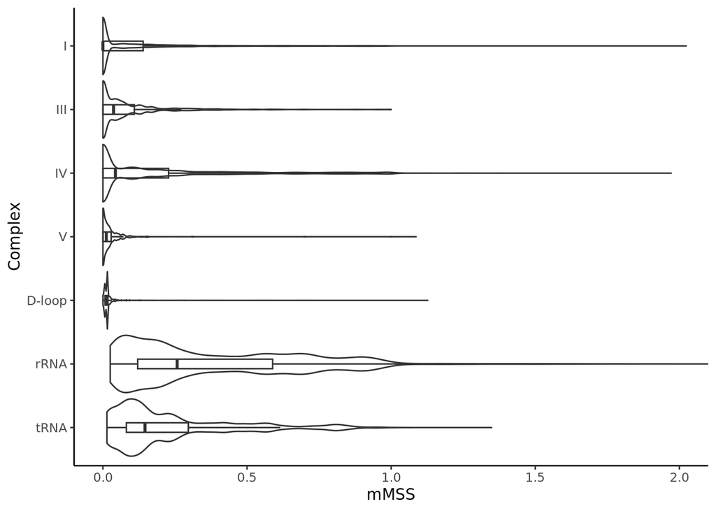

```r
ukb_mss_long <-
  ukb |>
  dplyr::select(id, starts_with("mMSS_complex_")) |>
  pivot_longer(
    cols = !id,
    names_to = "variable_mss",
    values_to = "value_mss"
  ) |>
  mutate(
    complex = str_remove(variable_mss, "mMSS_complex_")
  ) |>
  left_join(ukb_hc_long, by = c("id", "complex"))

ukb_mss_long |>
  filter(value != 0) |>
  mutate(
    variable_mss = str_remove(variable_mss, "mMSS_complex_"),
    variable_mss = factor(
      variable_mss,
      levels = rev(c("I", "III", "IV", "V", "DLOOP", "RRNA", "TRNA")),
      labels = rev(c("I", "III", "IV", "V", "D-loop", "rRNA", "tRNA"))
    )
  ) |>
  ggplot() +
  geom_violin(aes(x = value_mss, y = variable_mss), scale = "width") +
  geom_boxplot(aes(x = value_mss, y = variable_mss), alpha = 0, width = 0.15) +
  theme_classic() +
  scale_x_continuous("mMSS", breaks = c(0, 0.5, 1, 1.5, 2)) +
  scale_y_discrete("Complex") +
  coord_cartesian(xlim = c(0, 2))
```

## 7.3 Figure 2e

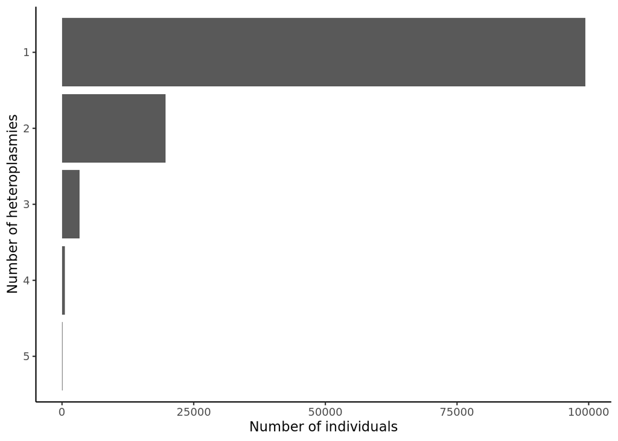

```r
ukb |>
  group_by(count_het) |>
  summarise(
    n = n()
  ) |>
  ungroup() |>
  filter(count_het != 0) |>
  ggplot() +
  geom_col(aes(x = n, y = reorder(count_het, -count_het))) +
  theme_classic() +
  scale_x_continuous("Number of individuals") +
  scale_y_discrete("Number of heteroplasmies")
```

# 8 Figure 3 - Association between CHIP and heteroplasmy

## 8.1 Figure 3a

```r
ukb |>
  janitor::tabyl(chip_yn, het_yn) |>
  janitor::adorn_percentages("all") |>
  janitor::adorn_pct_formatting(digits = 2) |>
  janitor::adorn_ns()
```

```
##  chip_yn                0                1
##        0 66.59% (289,183) 25.68% (111,524)
##        1  5.10%  (22,152)  2.64%  (11,445)
```

## 8.2 Figure 3c

```r
# No CHIP vs. CHIP
ukb |>
  janitor::tabyl(chip_yn, het_yn)
```

```
##  chip_yn      0      1
##        0 289183 111524
##        1  22152  11445
```

```r
glm(het_yn ~ chip_yn + rms::rcs(age, 5) + sex + smk_ever + prev_cancer_yn, data = ukb, family = binomial) |>
  summary()
```

```
##
## Call:
## glm(formula = het_yn ~ chip_yn + rms::rcs(age, 5) + sex + smk_ever +
##     prev_cancer_yn, family = binomial, data = ukb)
##
## Coefficients:
##                         Estimate Std. Error z value Pr(>|z|)
## (Intercept)            -1.399638   0.112058 -12.490  < 2e-16 ***
## chip_yn                 0.254825   0.012105  21.050  < 2e-16 ***
## rms::rcs(age, 5)age     0.006125   0.002470   2.479   0.0132 *
## rms::rcs(age, 5)age'    0.006337   0.008934   0.709   0.4782
## rms::rcs(age, 5)age''   0.010343   0.038330   0.270   0.7873
## rms::rcs(age, 5)age''' -0.031462   0.083898  -0.375   0.7077
## sexmen                  0.015013   0.006817   2.202   0.0276 *
## smk_everyes             0.044478   0.006953   6.397 1.59e-10 ***
## prev_cancer_yn1         0.053827   0.013054   4.123 3.73e-05 ***
## ---
## Signif. codes:  0 '***' 0.001 '**' 0.01 '*' 0.05 '.' 0.1 ' ' 1
##
## (Dispersion parameter for binomial family taken to be 1)
##
##     Null deviance: 517599  on 434303  degrees of freedom
## Residual deviance: 515790  on 434295  degrees of freedom
## AIC: 515808
##
## Number of Fisher Scoring iterations: 4
```

```r
# 2% <= VAF < 20% vs. VAF >= 20%
ukb |>
  filter(max_vaf_cat != 0) |>
  janitor::tabyl(max_vaf_cat, het_yn)
```

```
##  max_vaf_cat     0    1
##            1 19215 9131
##            2  2937 2314
```

```r
glm(het_yn ~ max_vaf_cat + rms::rcs(age, 5) + sex + smk_ever + prev_cancer_yn, data = ukb, subset = max_vaf_cat != 0, family = binomial) |>
  summary()
```

```
##
## Call:
## glm(formula = het_yn ~ max_vaf_cat + rms::rcs(age, 5) + sex +
##     smk_ever + prev_cancer_yn, family = binomial, data = ukb,
##     subset = max_vaf_cat != 0)
##
## Coefficients:
##                         Estimate Std. Error z value Pr(>|z|)
## (Intercept)            -2.541703   0.491839  -5.168 2.37e-07 ***
## max_vaf_cat             0.466501   0.030779  15.156  < 2e-16 ***
## rms::rcs(age, 5)age     0.021058   0.010717   1.965  0.04943 *
## rms::rcs(age, 5)age'   -0.005805   0.035870  -0.162  0.87143
## rms::rcs(age, 5)age''   0.034610   0.145418   0.238  0.81188
## rms::rcs(age, 5)age''' -0.001738   0.292430  -0.006  0.99526
## sexmen                  0.066465   0.023537   2.824  0.00475 **
## smk_everyes             0.066101   0.024265   2.724  0.00645 **
## prev_cancer_yn1         0.068102   0.040617   1.677  0.09360 .
## ---
## Signif. codes:  0 '***' 0.001 '**' 0.01 '*' 0.05 '.' 0.1 ' ' 1
##
## (Dispersion parameter for binomial family taken to be 1)
##
##     Null deviance: 43103  on 33596  degrees of freedom
## Residual deviance: 42548  on 33588  degrees of freedom
## AIC: 42566
##
## Number of Fisher Scoring iterations: 4
```

```r
# Single vs. multiple mutations
ukb <-
  ukb |>
  mutate(chip_multi = ifelse(chip_count <= 1, 0, 1))

ukb |>
  filter(chip_yn == 1) |>
  janitor::tabyl(chip_multi, het_yn)
```

```
##  chip_multi     0     1
##           0 20413 10311
##           1  1739  1134
```

```r
glm(het_yn ~ chip_multi + rms::rcs(age, 5) + sex + smk_ever + prev_cancer_yn, data = ukb, subset = chip_yn == 1, family = binomial) |>
  summary()
```

```
##
## Call:
## glm(formula = het_yn ~ chip_multi + rms::rcs(age, 5) + sex +
##     smk_ever + prev_cancer_yn, family = binomial, data = ukb,
##     subset = chip_yn == 1)
##
## Coefficients:
##                         Estimate Std. Error z value Pr(>|z|)
## (Intercept)            -2.041094   0.489418  -4.170 3.04e-05 ***
## chip_multi              0.214083   0.040297   5.313 1.08e-07 ***
## rms::rcs(age, 5)age     0.021183   0.010690   1.982  0.04754 *
## rms::rcs(age, 5)age'   -0.004563   0.035773  -0.128  0.89850
## rms::rcs(age, 5)age''   0.033463   0.145006   0.231  0.81749
## rms::rcs(age, 5)age''' -0.005277   0.291548  -0.018  0.98556
## sexmen                  0.074299   0.023457   3.168  0.00154 **
## smk_everyes             0.069781   0.024190   2.885  0.00392 **
## prev_cancer_yn1         0.077148   0.040473   1.906  0.05663 .
## ---
## Signif. codes:  0 '***' 0.001 '**' 0.01 '*' 0.05 '.' 0.1 ' ' 1
##
## (Dispersion parameter for binomial family taken to be 1)
##
##     Null deviance: 43103  on 33596  degrees of freedom
## Residual deviance: 42746  on 33588  degrees of freedom
## AIC: 42764
##
## Number of Fisher Scoring iterations: 4
```

```r
# By gene
ukb |>
  janitor::tabyl(DNMT3A, het_yn)
```

```
##  DNMT3A      0      1
##       0 303872 119006
##       1   7463   3963
```

```r
ukb |>
  janitor::tabyl(TET2, het_yn)
```

```
##  TET2      0      1
##     0 307148 120535
##     1   4187   2434
```

```r
ukb |>
  janitor::tabyl(ASXL1, het_yn)
```

```
##  ASXL1      0      1
##      0 310376 122208
##      1    959    761
```

```r
ukb |>
  janitor::tabyl(PPM1D, het_yn)
```

```
##  PPM1D      0      1
##      0 310935 122714
##      1    400    255
```

```r
ukb |>
  janitor::tabyl(TP53, het_yn)
```

```
##  TP53      0      1
##     0 310873 122737
##     1    462    232
```

```r
ukb |>
  janitor::tabyl(SRSF2, het_yn)
```

```
##  SRSF2      0      1
##      0 311202 122786
##      1    133    183
```

```r
ukb |>
  janitor::tabyl(SF3B1, het_yn)
```

```
##  SF3B1      0      1
##      0 311226 122839
##      1    109    130
```

```r
ukb |>
  janitor::tabyl(U2AF1, het_yn)
```

```
##  U2AF1      0      1
##      0 311275 122907
##      1     60     62
```

```r
ukb <-
  ukb |>
  mutate(
    splice = ifelse(SRSF2 == 1 | SF3B1 == 1 | U2AF1 == 1, 1, 0)
  )
glm(het_yn ~ splice + rms::rcs(age, 5) + sex + smk_ever + prev_cancer_yn, data = ukb, family = binomial) |>
  summary()
```

```
##
## Call:
## glm(formula = het_yn ~ splice + rms::rcs(age, 5) + sex + smk_ever +
##     prev_cancer_yn, family = binomial, data = ukb)
##
## Coefficients:
##                         Estimate Std. Error z value Pr(>|z|)
## (Intercept)            -1.404349   0.112030 -12.535  < 2e-16 ***
## splice                  1.033621   0.077766  13.291  < 2e-16 ***
## rms::rcs(age, 5)age     0.006529   0.002470   2.644   0.0082 **
## rms::rcs(age, 5)age'    0.006324   0.008932   0.708   0.4789
## rms::rcs(age, 5)age''   0.011838   0.038319   0.309   0.7574
## rms::rcs(age, 5)age''' -0.036961   0.083876  -0.441   0.6595
## sexmen                  0.011891   0.006816   1.745   0.0811 .
## smk_everyes             0.045751   0.006951   6.582 4.64e-11 ***
## prev_cancer_yn1         0.055895   0.013049   4.283 1.84e-05 ***
## ---
## Signif. codes:  0 '***' 0.001 '**' 0.01 '*' 0.05 '.' 0.1 ' ' 1
##
## (Dispersion parameter for binomial family taken to be 1)
##
##     Null deviance: 517599  on 434303  degrees of freedom
## Residual deviance: 516048  on 434295  degrees of freedom
## AIC: 516066
##
## Number of Fisher Scoring iterations: 4
```

```r
glm(het_yn ~ splice + rms::rcs(age, 5) + sex + smk_ever + prev_cancer_yn, data = ukb, subset = chip_yn == 1, family = binomial) |>
  summary()
```

```
##
## Call:
## glm(formula = het_yn ~ splice + rms::rcs(age, 5) + sex + smk_ever +
##     prev_cancer_yn, family = binomial, data = ukb, subset = chip_yn ==
##     1)
##
## Coefficients:
##                         Estimate Std. Error z value Pr(>|z|)
## (Intercept)            -2.029150   0.489516  -4.145 3.39e-05 ***
## splice                  0.769367   0.079116   9.724  < 2e-16 ***
## rms::rcs(age, 5)age     0.021289   0.010693   1.991   0.0465 *
## rms::rcs(age, 5)age'   -0.006771   0.035790  -0.189   0.8499
## rms::rcs(age, 5)age''   0.044136   0.145102   0.304   0.7610
## rms::rcs(age, 5)age''' -0.036037   0.291850  -0.123   0.9017
## sexmen                  0.058563   0.023551   2.487   0.0129 *
## smk_everyes             0.068964   0.024214   2.848   0.0044 **
## prev_cancer_yn1         0.083123   0.040506   2.052   0.0402 *
## ---
## Signif. codes:  0 '***' 0.001 '**' 0.01 '*' 0.05 '.' 0.1 ' ' 1
##
## (Dispersion parameter for binomial family taken to be 1)
##
##     Null deviance: 43103  on 33596  degrees of freedom
## Residual deviance: 42679  on 33588  degrees of freedom
## AIC: 42697
##
## Number of Fisher Scoring iterations: 4
```

## 8.3 Figure 3e

```r
ukb <-
  ukb |>
  mutate(
    multi_het = ifelse(count_het >=2, 1, 0)
  )

# No CHIP vs. CHIP
ukb |>
  janitor::tabyl(chip_yn, multi_het)
```

```
##  chip_yn      0     1
##        0 379824 20883
##        1  30838  2759
```

```r
glm(multi_het ~ chip_yn + rms::rcs(age, 5) + sex + smk_ever + prev_cancer_yn, data = ukb, family = binomial) |>
  summary()
```

```
##
## Call:
## glm(formula = multi_het ~ chip_yn + rms::rcs(age, 5) + sex +
##     smk_ever + prev_cancer_yn, family = binomial, data = ukb)
##
## Coefficients:
##                         Estimate Std. Error z value Pr(>|z|)
## (Intercept)            -3.864401   0.242613 -15.928  < 2e-16 ***
## chip_yn                 0.421166   0.021241  19.828  < 2e-16 ***
## rms::rcs(age, 5)age     0.013196   0.005334   2.474   0.0134 *
## rms::rcs(age, 5)age'    0.017393   0.018771   0.927   0.3541
## rms::rcs(age, 5)age''  -0.046775   0.078758  -0.594   0.5526
## rms::rcs(age, 5)age'''  0.142725   0.166335   0.858   0.3909
## sexmen                  0.071764   0.013510   5.312 1.09e-07 ***
## smk_everyes             0.109332   0.013973   7.825 5.10e-15 ***
## prev_cancer_yn1         0.116052   0.024352   4.766 1.88e-06 ***
## ---
## Signif. codes:  0 '***' 0.001 '**' 0.01 '*' 0.05 '.' 0.1 ' ' 1
##
## (Dispersion parameter for binomial family taken to be 1)
##
##     Null deviance: 183603  on 434303  degrees of freedom
## Residual deviance: 182089  on 434295  degrees of freedom
## AIC: 182107
##
## Number of Fisher Scoring iterations: 5
```

```r
# 2% <= VAF < 20% vs. VAF >= 20%
ukb |>
  filter(max_vaf_cat != 0) |>
  janitor::tabyl(max_vaf_cat, multi_het)
```

```
##  max_vaf_cat     0    1
##            1 26297 2049
##            2  4541  710
```

```r
glm(multi_het ~ max_vaf_cat + rms::rcs(age, 5) + sex + smk_ever + prev_cancer_yn, data = ukb, subset = max_vaf_cat != 0, family = binomial) |>
  summary()
```

```
##
## Call:
## glm(formula = multi_het ~ max_vaf_cat + rms::rcs(age, 5) + sex +
##     smk_ever + prev_cancer_yn, family = binomial, data = ukb,
##     subset = max_vaf_cat != 0)
##
## Coefficients:
##                        Estimate Std. Error z value Pr(>|z|)
## (Intercept)            -5.19106    0.99171  -5.234 1.65e-07 ***
## max_vaf_cat             0.63538    0.04678  13.583  < 2e-16 ***
## rms::rcs(age, 5)age     0.03031    0.02154   1.407 0.159429
## rms::rcs(age, 5)age'   -0.01455    0.06943  -0.210 0.833970
## rms::rcs(age, 5)age''   0.11918    0.27324   0.436 0.662704
## rms::rcs(age, 5)age''' -0.26845    0.52312  -0.513 0.607827
## sexmen                  0.14181    0.04045   3.506 0.000456 ***
## smk_everyes             0.13482    0.04264   3.162 0.001569 **
## prev_cancer_yn1         0.10095    0.06597   1.530 0.125964
## ---
## Signif. codes:  0 '***' 0.001 '**' 0.01 '*' 0.05 '.' 0.1 ' ' 1
##
## (Dispersion parameter for binomial family taken to be 1)
##
##     Null deviance: 19078  on 33596  degrees of freedom
## Residual deviance: 18651  on 33588  degrees of freedom
## AIC: 18669
##
## Number of Fisher Scoring iterations: 5
```

```r
# Single vs. multiple mutations
ukb |>
  filter(chip_yn == 1) |>
  janitor::tabyl(chip_multi, multi_het)
```

```
##  chip_multi     0    1
##           0 28306 2418
##           1  2532  341
```

```r
glm(multi_het ~ chip_multi + rms::rcs(age, 5) + sex + smk_ever + prev_cancer_yn, data = ukb, subset = chip_yn == 1, family = binomial) |>
  summary()
```

```
##
## Call:
## glm(formula = multi_het ~ chip_multi + rms::rcs(age, 5) + sex +
##     smk_ever + prev_cancer_yn, family = binomial, data = ukb,
##     subset = chip_yn == 1)
##
## Coefficients:
##                        Estimate Std. Error z value Pr(>|z|)
## (Intercept)            -4.50936    0.98887  -4.560 5.11e-06 ***
## chip_multi              0.39402    0.06186   6.370 1.89e-10 ***
## rms::rcs(age, 5)age     0.03056    0.02151   1.421 0.155437
## rms::rcs(age, 5)age'   -0.01305    0.06931  -0.188 0.850701
## rms::rcs(age, 5)age''   0.11933    0.27274   0.438 0.661737
## rms::rcs(age, 5)age''' -0.28034    0.52209  -0.537 0.591295
## sexmen                  0.15403    0.04033   3.819 0.000134 ***
## smk_everyes             0.14034    0.04254   3.299 0.000969 ***
## prev_cancer_yn1         0.11280    0.06578   1.715 0.086374 .
## ---
## Signif. codes:  0 '***' 0.001 '**' 0.01 '*' 0.05 '.' 0.1 ' ' 1
##
## (Dispersion parameter for binomial family taken to be 1)
##
##     Null deviance: 19078  on 33596  degrees of freedom
## Residual deviance: 18783  on 33588  degrees of freedom
## AIC: 18801
##
## Number of Fisher Scoring iterations: 5
```

```r
# By gene
ukb |>
  janitor::tabyl(DNMT3A, multi_het)
```

```
##  DNMT3A      0     1
##       0 400218 22660
##       1  10444   982
```

```r
ukb |>
  janitor::tabyl(TET2, multi_het)
```

```
##  TET2      0     1
##     0 404667 23016
##     1   5995   626
```

```r
ukb |>
  janitor::tabyl(ASXL1, multi_het)
```

```
##  ASXL1      0     1
##      0 409170 23414
##      1   1492   228
```

```r
ukb |>
  janitor::tabyl(PPM1D, multi_het)
```

```
##  PPM1D      0     1
##      0 410079 23570
##      1    583    72
```

```r
ukb |>
  janitor::tabyl(TP53, multi_het)
```

```
##  TP53      0     1
##     0 410034 23576
##     1    628    66
```

```r
ukb |>
  janitor::tabyl(SRSF2, multi_het)
```

```
##  SRSF2      0     1
##      0 410424 23564
##      1    238    78
```

```r
ukb |>
  janitor::tabyl(SF3B1, multi_het)
```

```
##  SF3B1      0     1
##      0 410470 23595
##      1    192    47
```

```r
ukb |>
  janitor::tabyl(U2AF1, multi_het)
```

```
##  U2AF1      0     1
##      0 410561 23621
##      1    101    21
```

```r
glm(multi_het ~ splice + rms::rcs(age, 5) + sex + smk_ever + prev_cancer_yn, data = ukb, family = binomial) |>
  summary()
```

```
##
## Call:
## glm(formula = multi_het ~ splice + rms::rcs(age, 5) + sex + smk_ever +
##     prev_cancer_yn, family = binomial, data = ukb)
##
## Coefficients:
##                         Estimate Std. Error z value Pr(>|z|)
## (Intercept)            -3.873000   0.242602 -15.964  < 2e-16 ***
## splice                  1.379212   0.094495  14.596  < 2e-16 ***
## rms::rcs(age, 5)age     0.013957   0.005333   2.617  0.00887 **
## rms::rcs(age, 5)age'    0.017234   0.018769   0.918  0.35851
## rms::rcs(age, 5)age''  -0.043353   0.078751  -0.551  0.58197
## rms::rcs(age, 5)age'''  0.130064   0.166319   0.782  0.43421
## sexmen                  0.065227   0.013516   4.826 1.39e-06 ***
## smk_everyes             0.111581   0.013970   7.987 1.38e-15 ***
## prev_cancer_yn1         0.120009   0.024345   4.930 8.24e-07 ***
## ---
## Signif. codes:  0 '***' 0.001 '**' 0.01 '*' 0.05 '.' 0.1 ' ' 1
##
## (Dispersion parameter for binomial family taken to be 1)
##
##     Null deviance: 183603  on 434303  degrees of freedom
## Residual deviance: 182287  on 434295  degrees of freedom
## AIC: 182305
##
## Number of Fisher Scoring iterations: 5
```

```r
glm(multi_het ~ splice + rms::rcs(age, 5) + sex + smk_ever + prev_cancer_yn, data = ukb, subset = chip_yn == 1, family = binomial) |>
  summary()
```

```
##
## Call:
## glm(formula = multi_het ~ splice + rms::rcs(age, 5) + sex + smk_ever +
##     prev_cancer_yn, family = binomial, data = ukb, subset = chip_yn ==
##     1)
##
## Coefficients:
##                        Estimate Std. Error z value Pr(>|z|)
## (Intercept)            -4.48131    0.98888  -4.532 5.85e-06 ***
## splice                  0.98189    0.09745  10.076  < 2e-16 ***
## rms::rcs(age, 5)age     0.03071    0.02151   1.428  0.15336
## rms::rcs(age, 5)age'   -0.01644    0.06933  -0.237  0.81254
## rms::rcs(age, 5)age''   0.13573    0.27290   0.497  0.61893
## rms::rcs(age, 5)age''' -0.32836    0.52259  -0.628  0.52978
## sexmen                  0.12456    0.04061   3.067  0.00216 **
## smk_everyes             0.13892    0.04258   3.262  0.00111 **
## prev_cancer_yn1         0.12507    0.06584   1.899  0.05750 .
## ---
## Signif. codes:  0 '***' 0.001 '**' 0.01 '*' 0.05 '.' 0.1 ' ' 1
##
## (Dispersion parameter for binomial family taken to be 1)
##
##     Null deviance: 19078  on 33596  degrees of freedom
## Residual deviance: 18735  on 33588  degrees of freedom
## AIC: 18753
##
## Number of Fisher Scoring iterations: 5
```

## 8.4 Figure 3g

```r
ukb <-
  ukb |>
  mutate(
    log_mMSS = log10(mMSS + 1)
  )

# No CHIP vs. CHIP
glm(log_mMSS ~ chip_yn + rms::rcs(age, 5) + sex + smk_ever + prev_cancer_yn, data = ukb) |>
  summary()
```

```
##
## Call:
## glm(formula = log_mMSS ~ chip_yn + rms::rcs(age, 5) + sex + smk_ever +
##     prev_cancer_yn, data = ukb)
##
## Coefficients:
##                          Estimate Std. Error t value Pr(>|t|)
## (Intercept)             3.898e-03  2.331e-03   1.672   0.0945 .
## chip_yn                 1.004e-02  2.717e-04  36.949  < 2e-16 ***
## rms::rcs(age, 5)age     9.846e-05  5.144e-05   1.914   0.0556 .
## rms::rcs(age, 5)age'    4.430e-04  1.878e-04   2.359   0.0183 *
## rms::rcs(age, 5)age''  -9.729e-04  8.125e-04  -1.198   0.2311
## rms::rcs(age, 5)age'''  3.774e-03  1.802e-03   2.094   0.0363 *
## sexmen                  6.556e-04  1.461e-04   4.489 7.17e-06 ***
## smk_everyes             1.491e-03  1.485e-04  10.037  < 2e-16 ***
## prev_cancer_yn1         1.949e-03  2.855e-04   6.824 8.86e-12 ***
## ---
## Signif. codes:  0 '***' 0.001 '**' 0.01 '*' 0.05 '.' 0.1 ' ' 1
##
## (Dispersion parameter for gaussian family taken to be 0.002270523)
##
##     Null deviance: 996.24  on 434303  degrees of freedom
## Residual deviance: 986.08  on 434295  degrees of freedom
## AIC: -1411420
##
## Number of Fisher Scoring iterations: 2
```

```r
# 2% <= VAF < 20% vs. VAF >= 20%
glm(log_mMSS ~ max_vaf_cat + rms::rcs(age, 5) + sex + smk_ever + prev_cancer_yn, data = ukb, subset = max_vaf_cat != 0) |>
  summary()
```

```
##
## Call:
## glm(formula = log_mMSS ~ max_vaf_cat + rms::rcs(age, 5) + sex +
##     smk_ever + prev_cancer_yn, data = ukb, subset = max_vaf_cat !=
##     0)
##
## Coefficients:
##                          Estimate Std. Error t value Pr(>|t|)
## (Intercept)            -0.0262056  0.0143567  -1.825  0.06796 .
## max_vaf_cat             0.0230616  0.0009921  23.245  < 2e-16 ***
## rms::rcs(age, 5)age     0.0002223  0.0003134   0.709  0.47821
## rms::rcs(age, 5)age'    0.0015939  0.0010675   1.493  0.13541
## rms::rcs(age, 5)age''  -0.0057698  0.0043808  -1.317  0.18783
## rms::rcs(age, 5)age'''  0.0139007  0.0089730   1.549  0.12135
## sexmen                  0.0031485  0.0007291   4.318 1.58e-05 ***
## smk_everyes             0.0020862  0.0007474   2.791  0.00525 **
## prev_cancer_yn1         0.0039968  0.0012817   3.118  0.00182 **
## ---
## Signif. codes:  0 '***' 0.001 '**' 0.01 '*' 0.05 '.' 0.1 ' ' 1
##
## (Dispersion parameter for gaussian family taken to be 0.004330804)
##
##     Null deviance: 150.21  on 33596  degrees of freedom
## Residual deviance: 145.46  on 33588  degrees of freedom
## AIC: -87480
##
## Number of Fisher Scoring iterations: 2
```

```r
# Single vs. multiple mutations
glm(log_mMSS ~ chip_multi + rms::rcs(age, 5) + sex + smk_ever + prev_cancer_yn, data = ukb, subset = chip_yn == 1) |>
  summary()
```

```
##
## Call:
## glm(formula = log_mMSS ~ chip_multi + rms::rcs(age, 5) + sex +
##     smk_ever + prev_cancer_yn, data = ukb, subset = chip_yn ==
##     1)
##
## Coefficients:
##                          Estimate Std. Error t value Pr(>|t|)
## (Intercept)            -0.0020092  0.0144025  -0.140 0.889055
## chip_multi              0.0151484  0.0012940  11.707  < 2e-16 ***
## rms::rcs(age, 5)age     0.0002301  0.0003153   0.730 0.465466
## rms::rcs(age, 5)age'    0.0016388  0.0010738   1.526 0.127000
## rms::rcs(age, 5)age''  -0.0057657  0.0044070  -1.308 0.190778
## rms::rcs(age, 5)age'''  0.0136014  0.0090266   1.507 0.131867
## sexmen                  0.0035055  0.0007332   4.781 1.75e-06 ***
## smk_everyes             0.0022649  0.0007518   3.013 0.002592 **
## prev_cancer_yn1         0.0043699  0.0012893   3.389 0.000701 ***
## ---
## Signif. codes:  0 '***' 0.001 '**' 0.01 '*' 0.05 '.' 0.1 ' ' 1
##
## (Dispersion parameter for gaussian family taken to be 0.00438259)
##
##     Null deviance: 150.21  on 33596  degrees of freedom
## Residual deviance: 147.20  on 33588  degrees of freedom
## AIC: -87080
##
## Number of Fisher Scoring iterations: 2
```

```r
# By gene
glm(log_mMSS ~ splice + rms::rcs(age, 5) + sex + smk_ever + prev_cancer_yn, data = ukb) |>
  summary()
```

```
##
## Call:
## glm(formula = log_mMSS ~ splice + rms::rcs(age, 5) + sex + smk_ever +
##     prev_cancer_yn, data = ukb)
##
## Coefficients:
##                          Estimate Std. Error t value Pr(>|t|)
## (Intercept)             3.717e-03  2.333e-03   1.593 0.111070
## splice                  5.417e-02  1.841e-03  29.426  < 2e-16 ***
## rms::rcs(age, 5)age     1.138e-04  5.147e-05   2.210 0.027094 *
## rms::rcs(age, 5)age'    4.400e-04  1.879e-04   2.341 0.019223 *
## rms::rcs(age, 5)age''  -9.042e-04  8.130e-04  -1.112 0.266022
## rms::rcs(age, 5)age'''  3.516e-03  1.803e-03   1.950 0.051177 .
## sexmen                  5.241e-04  1.462e-04   3.586 0.000336 ***
## smk_everyes             1.537e-03  1.486e-04  10.341  < 2e-16 ***
## prev_cancer_yn1         2.028e-03  2.857e-04   7.099 1.26e-12 ***
## ---
## Signif. codes:  0 '***' 0.001 '**' 0.01 '*' 0.05 '.' 0.1 ' ' 1
##
## (Dispersion parameter for gaussian family taken to be 0.002273128)
##
##     Null deviance: 996.24  on 434303  degrees of freedom
## Residual deviance: 987.21  on 434295  degrees of freedom
## AIC: -1410922
##
## Number of Fisher Scoring iterations: 2
```

```r
glm(log_mMSS ~ splice + rms::rcs(age, 5) + sex + smk_ever + prev_cancer_yn, data = ukb, subset = chip_yn == 1) |>
  summary()
```

```
##
## Call:
## glm(formula = log_mMSS ~ splice + rms::rcs(age, 5) + sex + smk_ever +
##     prev_cancer_yn, data = ukb, subset = chip_yn == 1)
##
## Coefficients:
##                          Estimate Std. Error t value Pr(>|t|)
## (Intercept)            -0.0012847  0.0143723  -0.089 0.928775
## splice                  0.0432154  0.0025878  16.700  < 2e-16 ***
## rms::rcs(age, 5)age     0.0002382  0.0003146   0.757 0.449077
## rms::rcs(age, 5)age'    0.0015313  0.0010716   1.429 0.153019
## rms::rcs(age, 5)age''  -0.0052369  0.0043979  -1.191 0.233747
## rms::rcs(age, 5)age'''  0.0120335  0.0090084   1.336 0.181621
## sexmen                  0.0027097  0.0007335   3.694 0.000221 ***
## smk_everyes             0.0022231  0.0007502   2.963 0.003047 **
## prev_cancer_yn1         0.0047388  0.0012864   3.684 0.000230 ***
## ---
## Signif. codes:  0 '***' 0.001 '**' 0.01 '*' 0.05 '.' 0.1 ' ' 1
##
## (Dispersion parameter for gaussian family taken to be 0.004364237)
##
##     Null deviance: 150.21  on 33596  degrees of freedom
## Residual deviance: 146.59  on 33588  degrees of freedom
## AIC: -87221
##
## Number of Fisher Scoring iterations: 2
```

# 9 Supplementary Table 4 - Participant characteristics stratified by CHRS category in the UK Biobank.

```r
table1::table1(
  ~ age + sex + race_new + smk_ever + age65_yn + ccus + rdw_cat + mcv_cat + high_risk_fct + single_dnmt3a_fct + mutation_n_fct + max_vaf_fct +
    count_het + mMSS |
  chrs_cat,
  data = ukb_chip,
  overall = F,
  render.continuous = my.render.cont,
  extra.col = list(`P value` = pvalue)
  )
```

|  | low (N=30542) | intermediate (N=2821) | high (N=234) | P value |
| --- | --- | --- | --- | --- |
| Age (years) |  |  |  |  |
| Mean (SD) | 58.56 (± 7.559) | 61.71 (± 7.148) | 64.59 (± 4.675) | < 1e-04 |
| Sex (%) |  |  |  |  |
| women | 17113 (56.0%) | 1363 (48.3%) | 67 (28.6%) | < 1e-04 |
| men | 13429 (44.0%) | 1458 (51.7%) | 167 (71.4%) |  |
| Self-reported race (%) |  |  |  |  |
| white | 29198 (95.6%) | 2638 (93.5%) | 230 (98.3%) | < 1e-04 |
| black | 362 (1.2%) | 57 (2.0%) | 2 (0.9%) |  |
| asian | 534 (1.7%) | 67 (2.4%) | 2 (0.9%) |  |
| others | 354 (1.2%) | 40 (1.4%) | 0 (0%) |  |
| missing | 94 (0.3%) | 19 (0.7%) | 0 (0%) |  |
| Ever smoker (%) |  |  |  |  |
| no | 11612 (38.0%) | 970 (34.4%) | 57 (24.4%) | < 1e-04 |
| yes | 18930 (62.0%) | 1851 (65.6%) | 177 (75.6%) |  |
| Age 65+ (%) |  |  |  |  |
| 0 | 22860 (74.8%) | 1430 (50.7%) | 86 (36.8%) | < 1e-04 |
| 1 | 7682 (25.2%) | 1391 (49.3%) | 148 (63.2%) |  |
| CCUS (%) |  |  |  |  |
| chip | 28958 (94.8%) | 1978 (70.1%) | 98 (41.9%) | < 1e-04 |
| ccus | 1584 (5.2%) | 843 (29.9%) | 136 (58.1%) |  |
| RDW 15+ (%) |  |  |  |  |
| 0 | 0 (0%) | 0 (0%) | 0 (0%) | NA |
| 1 | 29742 (97.4%) | 1780 (63.1%) | 55 (23.5%) |  |
| 2.5 | 800 (2.6%) | 1041 (36.9%) | 179 (76.5%) |  |
| MCV 100+ (%) |  |  |  |  |
| 0 | 0 (0%) | 0 (0%) | 0 (0%) | NA |
| 1 | 30185 (98.8%) | 2430 (86.1%) | 147 (62.8%) |  |
| 2.5 | 357 (1.2%) | 391 (13.9%) | 87 (37.2%) |  |
| High-risk mutation (%) |  |  |  |  |
| no | 29834 (97.7%) | 1882 (66.7%) | 33 (14.1%) | < 1e-04 |
| yes | 708 (2.3%) | 939 (33.3%) | 201 (85.9%) |  |
| Single DNMT3A (%) |  |  |  |  |
| no | 20482 (67.1%) | 2652 (94.0%) | 231 (98.7%) | < 1e-04 |
| yes | 10060 (32.9%) | 169 (6.0%) | 3 (1.3%) |  |
| Number of mutations 2+ (%) |  |  |  |  |
| 1 | 28915 (94.7%) | 1731 (61.4%) | 78 (33.3%) | < 1e-04 |
| 2+ | 1627 (5.3%) | 1090 (38.6%) | 156 (66.7%) |  |
| VAF 20+ (%) |  |  |  |  |
| < 20 | 26848 (87.9%) | 1469 (52.1%) | 29 (12.4%) | < 1e-04 |
| 20+ | 3694 (12.1%) | 1352 (47.9%) | 205 (87.6%) |  |
| Heteroplasmy count |  |  |  |  |
| Mean (SD) | 0.4221 (± 0.6869) | 0.6228 (± 0.8494) | 1.090 (± 1.114) | < 1e-04 |
| mMSS |  |  |  |  |
| Mean (SD) | 0.06545 (± 0.1989) | 0.1409 (± 0.3147) | 0.3579 (± 0.5416) | < 1e-04 |

```r
# Heteroplasmy count: Q1, Q2, Q3
ukb_chip |>
  group_by(chrs_cat) |>
  summarise(

    median = median(count_het),
    p25 = quantile(count_het, probs = 0.25),
    p75 = quantile(count_het, probs = 0.75)
  )
```

```
## # A tibble: 3 x 4
##   chrs_cat     median   p25   p75
##   <fct>         <dbl> <dbl> <dbl>
## 1 low               0     0     1
## 2 intermediate      0     0     1
## 3 high              1     0     2
```

```r
chisq.test(ukb_chip$chrs_cat, ukb_chip$count_het, correct=FALSE)
```

```
##
##  Pearson's Chi-squared test
##
## data:  ukb_chip$chrs_cat and ukb_chip$count_het
## X-squared = 479.09, df = 10, p-value < 2.2e-16
```

```r
# mMSS: Q1, Q2, Q3
ukb_chip |>
  group_by(chrs_cat) |>
  summarise(
    median = median(mMSS),
    p25 = quantile(mMSS, probs = 0.25),
    p75 = quantile(mMSS, probs = 0.75)
  )
```

```
## # A tibble: 3 x 4
##   chrs_cat       median   p25       p75
##   <fct>           <dbl> <dbl>     <dbl>
## 1 low          0            0 0.0046257
## 2 intermediate 0            0 0.072617
## 3 high         0.016600     0 0.60297
```

```r
aov(mMSS ~ chrs_cat, data = ukb_chip) |>
  summary()
```

```
##                Df Sum Sq Mean Sq F value Pr(>F)
## chrs_cat        2   33.7  16.855   363.9 <2e-16 ***
## Residuals   33594 1556.0   0.046
## ---
## Signif. codes:  0 '***' 0.001 '**' 0.01 '*' 0.05 '.' 0.1 ' ' 1
```

# 10 Supplementary Figure 1 - Representation of the first 15 most frequently mutated genes

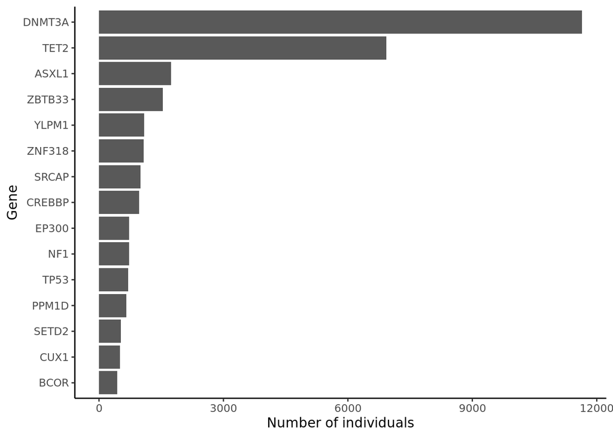

```r
chip_fq_sum |>
  filter(row_number() <= 15) |>
  ggplot() +
  geom_col(aes(x = reorder(Gene.refGene, n), y = n)) +
  theme_classic() +
  coord_flip() +
  scale_x_discrete("Gene") +
  scale_y_continuous("Number of individuals")
```

# 11 Supplementary Figure 9 - Distribution of heteroplasmy count and mMSS by CHRS category in the UKB.

## 11.1 Panel A

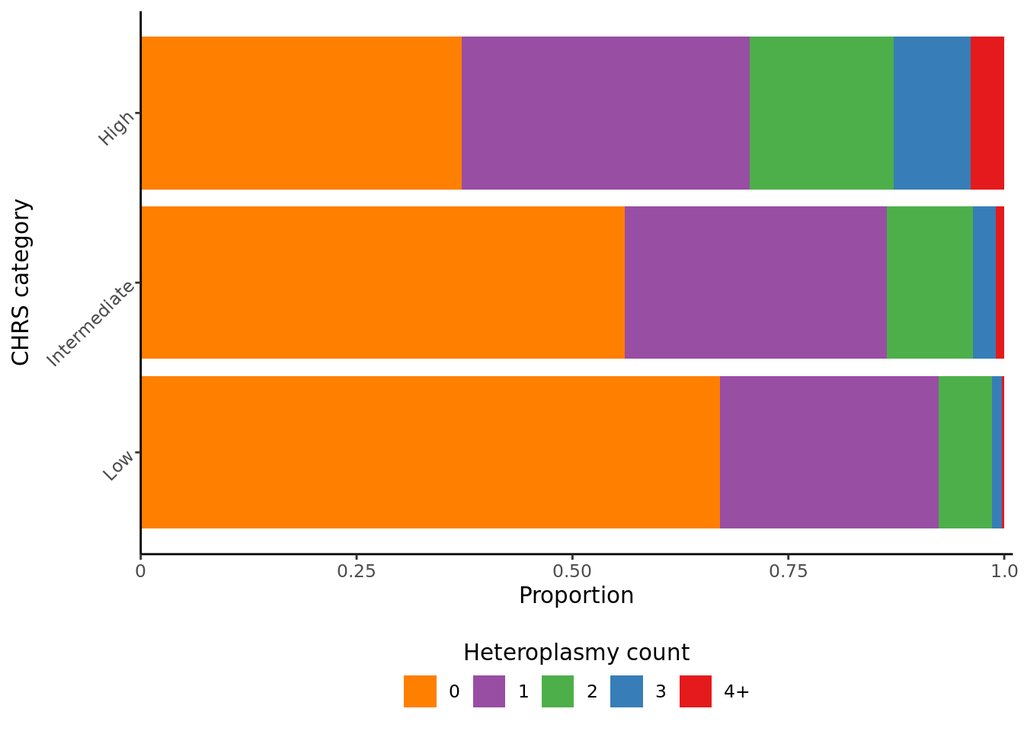

```r
count <-
  ukb |>
  filter(chip_yn == 1) |>
  mutate(
    count_het_cat = forcats::fct_rev(count_het_cat)
  ) |>
  ggplot() +
  geom_bar(aes(x = chrs_cat, fill = count_het_cat), position = "fill") +
  scale_x_discrete("CHRS category", labels=c("low" = "Low", "intermediate" = "Intermediate", "high" = "High")) +
  scale_y_continuous(
    "Proportion",
    breaks = c(0, 0.25, 0.5, 0.75, 1),
    labels = c("0", "0.25", "0.50", "0.75", "1.0"),
    limits = c(0, 1.01),
    expand = c(0, 0)
  ) +
  scale_fill_brewer("Heteroplasmy count", labels = c("4+", "3", "2", "1", "0"), palette = "Set1") +
  coord_flip() +
  theme_classic() +
  theme(legend.position = "bottom",
        axis.text.y = element_text(angle = 45, vjust = 0.5, hjust=1)) +
  guides(fill = guide_legend(title.position = "top", title.hjust = 0.5, nrow = 1, reverse = TRUE))
count
```

```r
count_table <-
  ukb_chip |>
  filter(chip_yn == 1) |>
  janitor::tabyl(count_het_cat, chrs_cat) |>
  janitor::adorn_percentages() |>
  janitor::adorn_ns() |>
  rename(
    Metric = count_het_cat
  )
```

## 11.2 Panel B

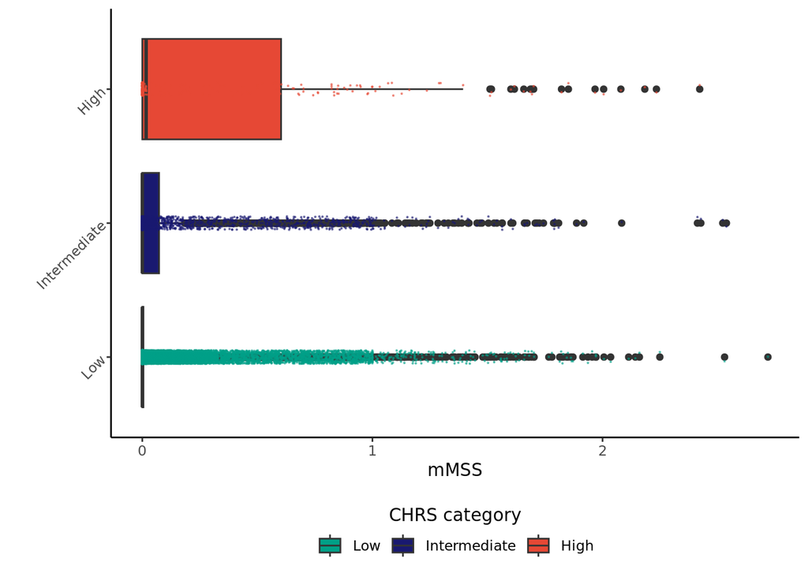

```r
mss <-
  ukb |>
  filter(chip_yn == 1) |>
  ggplot() +
  geom_boxplot(aes(x = chrs_cat, y = mMSS, fill = chrs_cat)) +
  coord_flip() +
  geom_jitter(aes(x = chrs_cat, y = mMSS, color = chrs_cat), size = 0.1, width = 0.05, alpha = 0.5) +
  scale_x_discrete("", labels=c("low" = "Low", "intermediate" = "Intermediate", "high" = "High")) +
  scale_y_continuous("mMSS") +
  scale_color_manual(
    "CHRS category",
    labels = c("Low", "Intermediate", "High"),
    values = c("#00A087FF", "#191970", "#E64835FF")
  ) +
  scale_fill_manual(
    "CHRS category",
    labels = c("Low", "Intermediate", "High"),
    values = c("#00A087FF", "#191970", "#E64835FF")
  ) +
  guides(color = "none") +
  theme_classic() +
  theme(legend.position = "bottom",
        axis.text.y = element_text(angle = 45, vjust = 0.5, hjust=1)) +
  guides(fill = guide_legend(title.position = "top", title.hjust = 0.5, nrow = 1))
mss
```

```r
mss_table <-
  ukb_chip |>
  group_by(chrs_cat) |>
  summarise(
    min = min(mMSS),
    q1 = quantile(mMSS, 0.25),
    median = median(mMSS),
    q3 = quantile(mMSS, 0.75),
    max = max(mMSS)
  ) |>
  t() |>
  as.data.frame() |>
  rownames_to_column() |>
  rename(
    Metric = rowname,
    low = V1,
    intermediate = V2,
    high = V3
  ) |>
  filter(Metric != "chrs_cat")
```

## 11.3 Combined

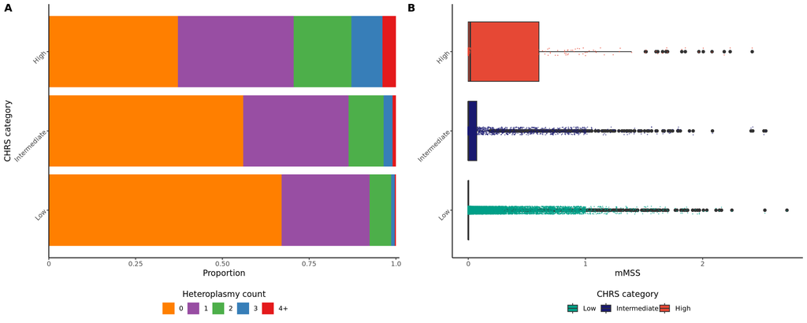

```r
combined <- ggpubr::ggarrange(count, mss, nrow = 1, labels = c("A", "B"), widths = c(1, 1))
combined
```

```r
table <-
  count_table |>
  bind_rows(mss_table) |>
  add_row(.before = 1) |>
  add_row(.before = 7) |>
  mutate(
    Metric = c("Heteroplasmy count", "0", "1", "2", "3", "4+", "mMSS", "Minimum", "Q2", "Median", "Q3", "Maximum")
  )

table |>
  openxlsx::write.xlsx("ukb_mthet_chip_source_data_file_01_descriptive.xlsx", sheetName = "Supplementary Figure 9")
```